# Clustering - Iris

Erick Marroquín

2026-01-30

# 1. Objetivo

El objetivo de este ejercicio es aplicar técnicas de clustering (aprendizaje no supervisado) al conjunto de datos Iris, realizando:

- Análisis Exploratorio de Datos (EDA)
- Preparación y estandarización de variables
- Determinación del número óptimo de clusters
- Construcción de modelos de clustering
- Validación y evaluación de los resultados

# 2. Carga de librerías y datos

```r
library(tidyverse)
library(cluster)
library(factoextra)
library(GGally)
```

```r
data(iris)
df <- iris
head(df)
```

```
##   Sepal.Length Sepal.Width Petal.Length Petal.Width Species
## 1          5.1         3.5          1.4         0.2  setosa
## 2          4.9         3.0          1.4         0.2  setosa
## 3          4.7         3.2          1.3         0.2  setosa
## 4          4.6         3.1          1.5         0.2  setosa
## 5          5.0         3.6          1.4         0.2  setosa
## 6          5.4         3.9          1.7         0.4  setosa
```

# 3. Análisis Exploratorio de Datos

## 3.1 Estructura del dataset

```r
str(df)
```

```
## 'data.frame':    150 obs. of  5 variables:
##  $ Sepal.Length: num  5.1 4.9 4.7 4.6 5 5.4 4.6 5 4.4 4.9 ...
##  $ Sepal.Width : num  3.5 3 3.2 3.1 3.6 3.9 3.4 3.4 2.9 3.1 ...
##  $ Petal.Length: num  1.4 1.4 1.3 1.5 1.4 1.7 1.4 1.5 1.4 1.5 ...
##  $ Petal.Width : num  0.2 0.2 0.2 0.2 0.2 0.4 0.3 0.2 0.2 0.1 ...
##  $ Species     : Factor w/ 3 levels "setosa","versicolor",..: 1 1 1 1 1 1 1 1 1 1 ...
```

```r
summary(df)
```

```
##   Sepal.Length    Sepal.Width     Petal.Length    Petal.Width
##  Min.   :4.300   Min.   :2.000   Min.   :1.000   Min.   :0.100
##  1st Qu.:5.100   1st Qu.:2.800   1st Qu.:1.600   1st Qu.:0.300
##  Median :5.800   Median :3.000   Median :4.350   Median :1.300
##  Mean   :5.843   Mean   :3.057   Mean   :3.758   Mean   :1.199
##  3rd Qu.:6.400   3rd Qu.:3.300   3rd Qu.:5.100   3rd Qu.:1.800
##  Max.   :7.900   Max.   :4.400   Max.   :6.900   Max.   :2.500
##        Species
##  setosa    :50
##  versicolor:50
##  virginica :50
##
##
##
```

El dataset contiene 150 observaciones y 5 variables, donde *Species* corresponde a la etiqueta real (que **no se usará para entrenar** el modelo de clustering).

## 3.2 Visualización exploratoria

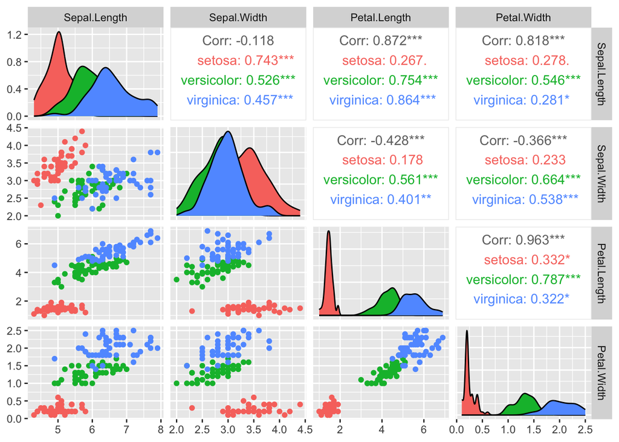

```r
GGally::ggpairs(df, columns = 1:4, aes(color = Species))
```

Se observa que algunas variables presentan separación natural entre especies, especialmente *Petal.Length* y *Petal.Width*.

# 4. Preparación de los datos

Para clustering solo se utilizan variables numéricas. Además, se estandarizan (mísma escala) para evitar sesgos por escala.

```r
df_num <- df %>% select(-Species)
df_scaled <- scale(df_num)
```

# 5. Determinación del número óptimo de clusters

## 5.1 Método del codo (Elbow Method)

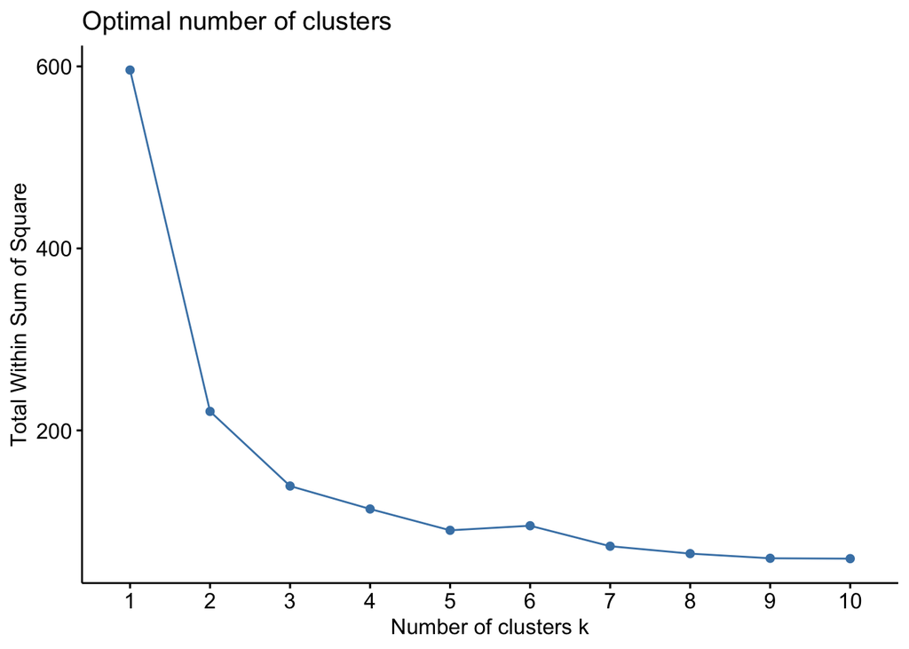

```r
fviz_nbclust(df_scaled, kmeans, method = "wss")
```

**Criterio de selección:**

El método del codo analiza la suma de cuadrados intra-cluster (WSS) para distintos valores de k. A medida que aumenta el número de clusters, la WSS disminuye porque los grupos son más pequeños y homogéneos.

El valor óptimo de k se identifica en el punto donde la disminución de la WSS deja de ser pronunciada y comienza a estabilizarse, formando un “codo” en la gráfica. A partir de ese punto, agregar más clusters no aporta una mejora significativa al modelo.

## 5.2 Método de la silueta

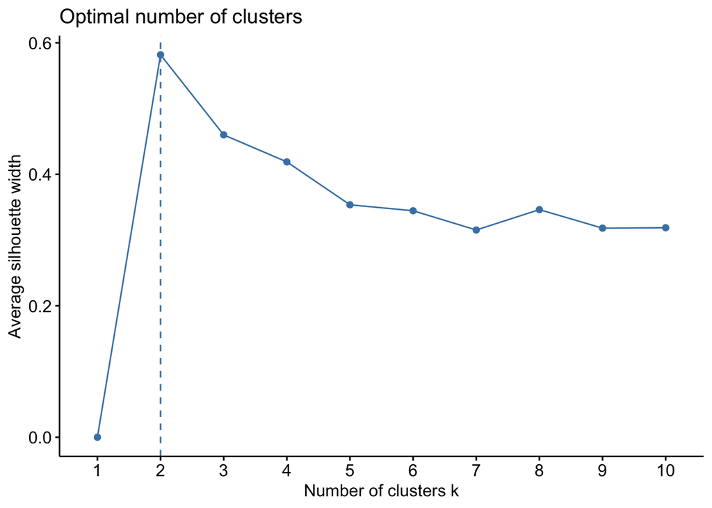

```r
fviz_nbclust(df_scaled, kmeans, method = "silhouette")
```

**Criterio de selección:**

El método de la silueta evalúa qué tan bien está asignada cada observación a su cluster. El coeficiente de silueta toma valores entre -1 y 1:

- Valores cercanos a **1** indican que la observación está bien agrupada.
- Valores cercanos a **0** indican solapamiento entre clusters.
- Valores negativos sugieren una mala asignación.

El número óptimo de clusters corresponde al valor de k que maximiza el coeficiente promedio de silueta, indicando una separación clara entre los grupos.

# 6. Clustering con K-means

## 6.1 ¿Cómo funciona el algoritmo K-means?

K-means es un algoritmo de aprendizaje no supervisado que busca particionar los datos en *k* clusters, minimizando la variabilidad interna de cada grupo. Su funcionamiento puede resumirse en los siguientes pasos:

1. **Inicialización:** Se seleccionan aleatoriamente *k* centroides iniciales.
2. **Asignación:** Cada observación se asigna al centroide más cercano (usualmente usando distancia euclidiana).
3. **Actualización:** Para cada cluster, se recalcula el centroide como el promedio de las observaciones asignadas.
4. **Iteración:** Los pasos 2 y 3 se repiten hasta que los centroides dejan de cambiar o se alcanza un criterio de convergencia.

El objetivo del algoritmo es minimizar la *suma de distancias cuadradas* entre cada observación y el centroide de su cluster.

## 6.2 Entrenamiento del modelo

```r
set.seed(123)
kmeans_model <- kmeans(df_scaled, centers = 3, nstart = 25)
```

```r
str(kmeans_model)
```

```
## List of 9
##  $ cluster     : int [1:150] 1 1 1 1 1 1 1 1 1 1 ...
##  $ centers     : num [1:3, 1:4] -1.0112 -0.0501 1.1322 0.8504 -0.8804 ...
##   ..- attr(*, "dimnames")=List of 2
##   .. ..$ : chr [1:3] "1" "2" "3"
##   .. ..$ : chr [1:4] "Sepal.Length" "Sepal.Width" "Petal.Length" "Petal.Width"
##  $ totss       : num 596
##  $ withinss    : num [1:3] 47.4 44.1 47.5
##  $ tot.withinss: num 139
##  $ betweenss   : num 457
##  $ size        : int [1:3] 50 53 47
##  $ iter        : int 2
##  $ ifault      : int 0
##  - attr(*, "class")= chr "kmeans"
```

## 6.1 Visualización de los clusters

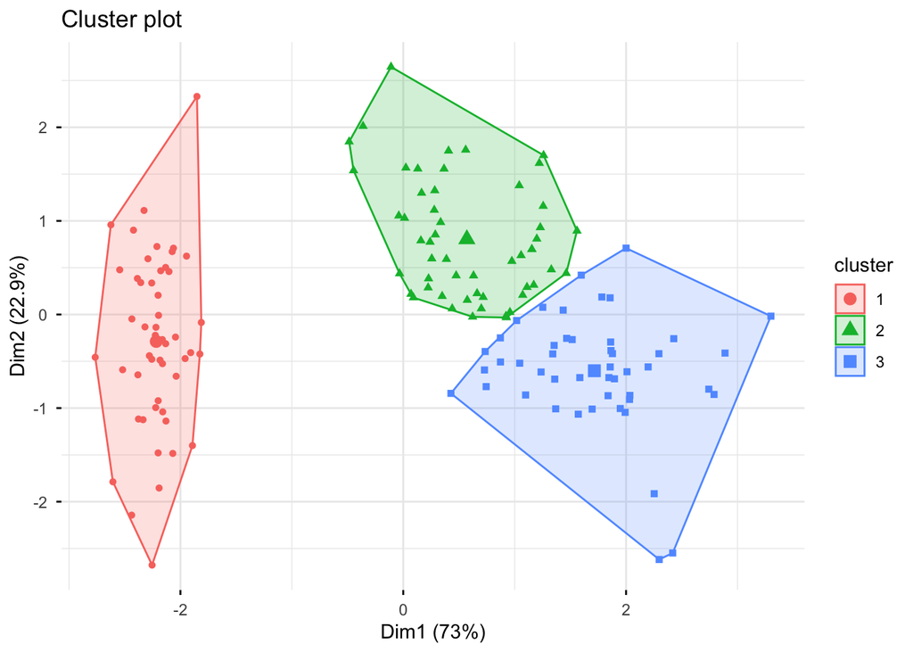

```r
fviz_cluster(kmeans_model, data = df_scaled,
             geom = "point",
             ellipse.type = "convex",
             ggtheme = theme_minimal())
```

# 7. Validación del clustering

## 7.1 Coeficiente de silueta

```r
sil <- silhouette(kmeans_model$cluster, dist(df_scaled))
summary(sil)
```

```
## Silhouette of 150 units in 3 clusters from silhouette.default(x = kmeans_model$cluster, dist = dist(df_scaled)) :
##  Cluster sizes and average silhouette widths:
##        50        53        47
## 0.6363162 0.3933772 0.3473922
## Individual silhouette widths:
##     Min.  1st Qu.   Median     Mean  3rd Qu.     Max.
## -0.02489  0.35914  0.47113  0.45995  0.58883  0.73419
```

En datos reales:

Valores > 0.7 → raro de encontrar

Valores > 0.5 → muy buenos

Valores 0.3 – 0.5 → aceptables / buenos

Valores < 0.25 → mal clustering

```
##   cluster size ave.sil.width
## 1       1   50          0.64
## 2       2   53          0.39
## 3       3   47          0.35
```

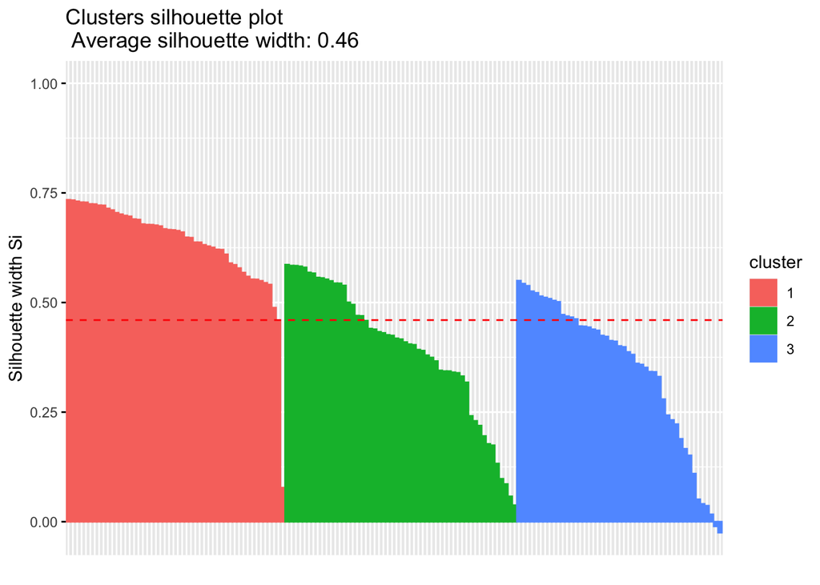

```r
fviz_silhouette(sil)
```

Valores positivos y cercanos a 1 indican una buena asignación de los clusters.

## 7.2 Comparación con las clases reales

> **Nota:** Esta comparación es solo con fines de evaluación, ya que el modelo es no supervisado.

```r
cluster_vs_species <- table(Cluster = kmeans_model$cluster, Species = df$Species)
cluster_vs_species
```

```
##        Species
## Cluster setosa versicolor virginica
##       1     50          0         0
##       2      0         39        14
##       3      0         11        36
```

Se observa una correspondencia razonable entre los clusters generados y las especies reales, especialmente para setosa.

# 8. Clustering jerárquico

```r
dist_matrix <- dist(df_scaled)
hc <- hclust(dist_matrix, method = "ward.D2")
```

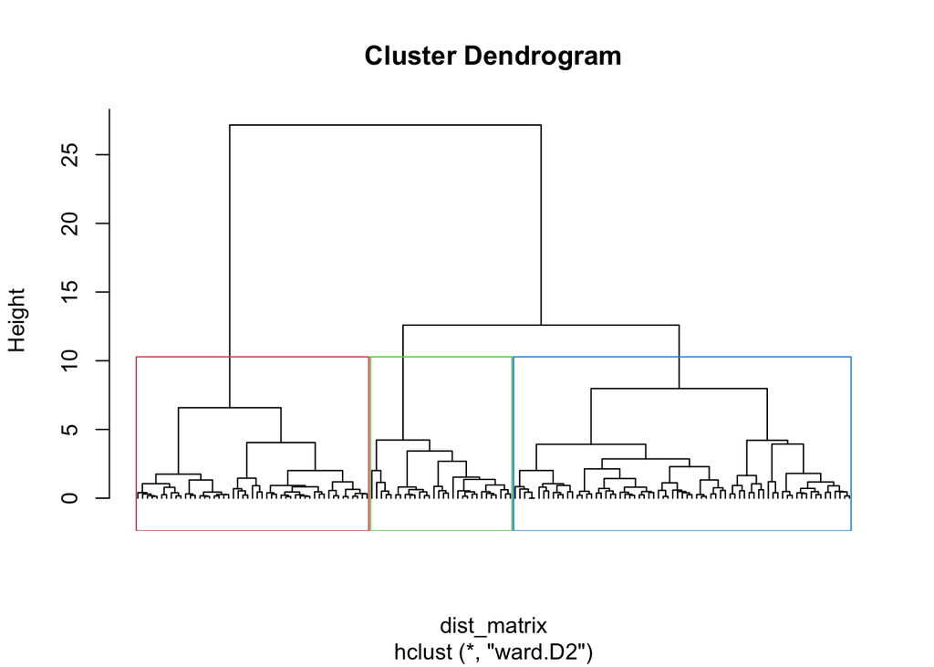

```r
plot(hc, labels = FALSE, hang = -1)
rect.hclust(hc, k = 3, border = 2:4)
```

# 9. Conclusiones

- La estandarización fue clave para aplicar clustering correctamente.
- K-means con k = 3 produce clusters coherentes con las especies reales.
- El coeficiente de silueta respalda la calidad de la clusterización.
- El clustering jerárquico confirma una estructura similar en los datos.

Este ejercicio demuestra cómo aplicar y validar técnicas de aprendizaje no supervisado sobre un dataset clásico.